# A Spatial Analysis of Available Hospital Beds Relative to the Population Distribution in Texas Using Adaptive Bandwidth Log-Relative Risks

Michael Tiefelsdorf & Amanuel Abuhay

2020-08-14

# 1 Introduction

## 1.1 Motivation

News paper articles frequently discuss health care access in Texas, e.g., [The Houston Public Media](https://www.houstonpublicmedia.org/articles/shows/houston-matters/2019/06/12/336482/report-texas-ranks-last-in-u-s-in-access-and-affordability-to-health-care/) in June 2019, [The Dallas Morning News](https://www.dallasnews.com/opinion/commentary/2019/12/31/solving-texas-rural-healthcare-crisis-will-require-more-collaboration/) in December 2019 and [The Dallas Morning News](https://www.dallasnews.com/business/health-care/2020/05/17/struggling-north-texas-rural-hospital-learns-feds-dont-want-it-to-get-paycheck-protection-money/) in May 2020:

- Texas has ranked last in access towards public health care and affordability.
- The Texas Department of Health and Human services estimates a statewide shortage of 3,375 primary care physicians in Texas by 2030.
- Some rural hospitals lack the financial resources to keep their doors open.
- Around 3 million people live in rural Texas. They need to drive long distances to see their doctors and in case of an emergency they rely on helicopter ambulances.

## 1.2 Objectives

- This study aims at identifying, depending on the location of hospitals, the ranges of their catchment areas.
- Furthermore, areas of significant over- or under-supply of hospital capacities relative to the demand of their underlying population will be detected.
- Potential causes for an unbalanced capacity distribution are evaluated.

## 1.3 Study Design

In contrast to other studies, a strict **supply** and **demand** approach is adopted in this study to evaluate spatial disparities in the provision of health care.

1. Kernel density smoothers are used, because several counties lack having hospitals and to allow for *cross-county spill-overs* of the supply and demand.
2. To account for a diverse distributions of the population and hospitals in a state as heterogeneous as Texas *adaptive bandwidth* kernel density smoothing needs to be employed.

   The detected adaptive bandwidths are estimating the spatial extent of the hospital’s catchment areas.

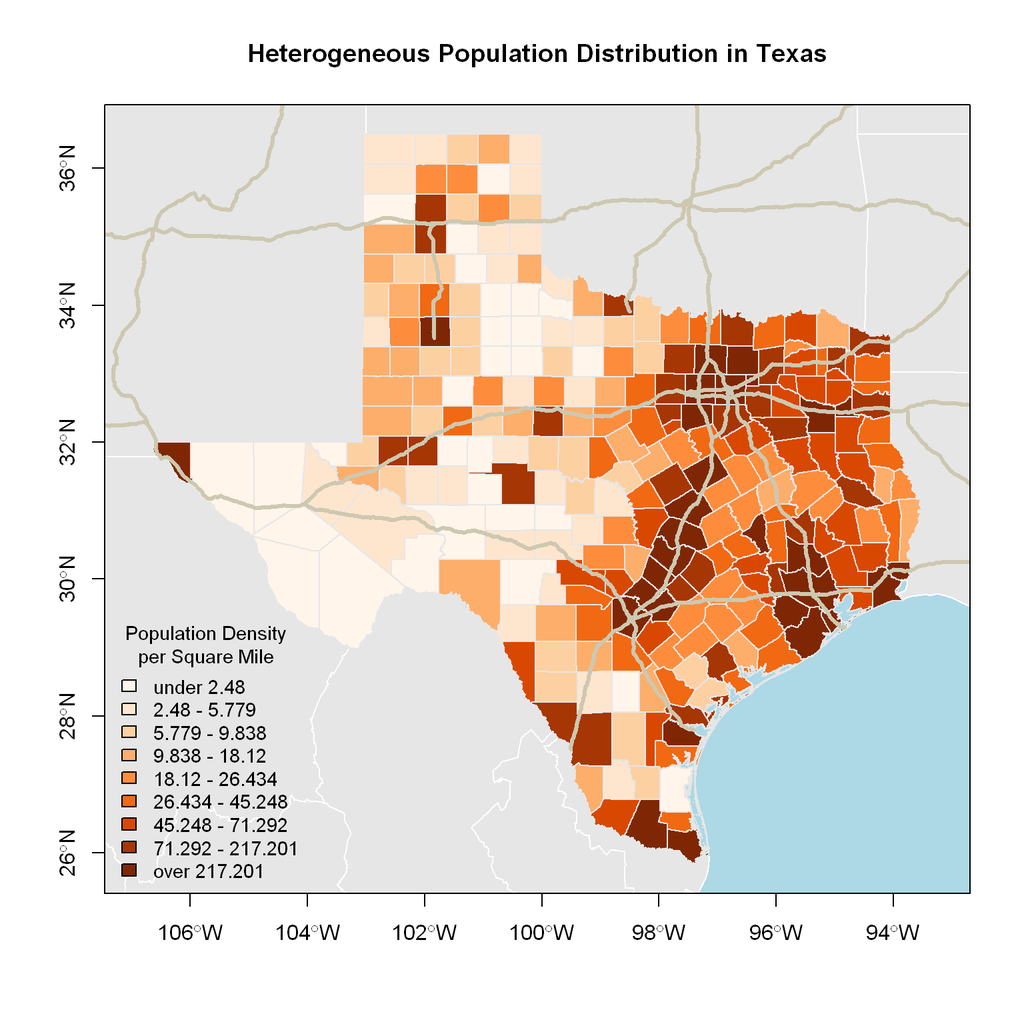

3. The *capacity weighted* kernel densities of the hospital distribution is compared against the *population weighted* density of the block-group centroids.

   This *relative risk ratio* assesses for each location in Texas its *hospital accessiblity*.
4. To account for *commuting flows* and *spatial spill-overs* of the population for health-care services across the Texas state line a *100 km guard buffer* around Texas is introduced. This guard buffer provides more realistic estimates of the *relative risk ratios* for the border counties in Texas.
5. Specific causes for a *deviation of from a balanced distribution* are evaluated using a heteroscedasticity adjusted linear regression model.

Geographic information system methodology and statistical methods available through several R-packages are employed in this study.

# 2 Relevant Map Layers

Most of this study’s data were obtained from [Caliper Inc.](http://www.caliper.com). Caliper Inc. pre-processed and augmented the [Center for Medicare & Medicaid Services](https://www.cms.gov/Research-Statistics-Data-and-Systems/Downloadable-Public-Use-Files/Cost-Reports/Hospital-2010-form) *Hospital Data* as well as the most recent *American Community Survey* data of the [U.S. Census Bureau](https://www.census.gov/).

Several map layers are needed for this state-wide *hospital accessibility* study in Texas:

The spatial distribution of hospital locations in Texas clearly indicates that hospitals follow the population and cluster predominantly in urban and metropolitan areas.

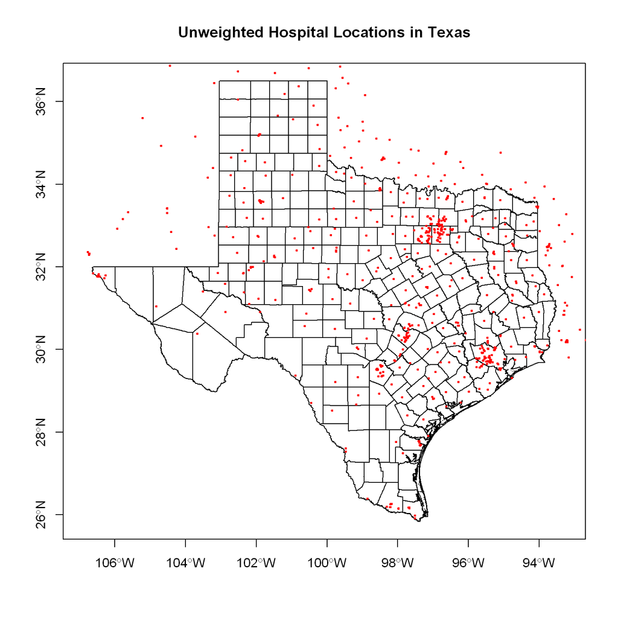

```r
## Check hospital locations
plot(countyShp, axes = TRUE, main = "Unweighted Hospital Locations in Texas")
points(hospitalShp, col = "red", pch = 20, cex = 0.5)
```

# 3 Data Preparations

## 3.1 Selection of Valid Hospitals

Only those hospitals, which serve the general population, are included in this analysis. Thus hospitals for veterans and U.S. army hospitals were removed from the dataset.

```r
## Original hospitalShp
summary(hospitalShp[c("CLOSED","BEDS","TYPE")])
```

```
## Object of class SpatialPointsDataFrame
## Coordinates:
##                  min       max
## coords.x1 -106.77198 -92.47945
## coords.x2   25.91707  37.40422
## Is projected: FALSE
## proj4string : [+proj=longlat +ellps=GRS80 +no_defs]
## Number of points: 793
## Data attributes:
##     CLOSED               BEDS            TYPE
##  Length:793         Min.   :   0.0   Length:793
##  Class :character   1st Qu.:  25.0   Class :character
##  Mode  :character   Median :  48.0   Mode  :character
##                     Mean   : 105.6
##                     3rd Qu.: 116.0
##                     Max.   :1502.0
##                     NA's   :3
```

```r
## Clean hospitalShp
hospitalShp <- hospitalShp[is.na(hospitalShp$CLOSED), ]    # Remove closed hospitals
hospitalShp <- hospitalShp[!is.na(hospitalShp$BEDS), ]     # Remove hopitals with NA beds
hospitalShp <- hospitalShp[hospitalShp$TYPE=="General" |   # Select only general hospitals
                             is.na(hospitalShp$TYPE), ]

# reduce Galveston by 300 beds, which are reserved for the TX prisoner population

## Updated hospitalShp
summary(hospitalShp[c("CLOSED","BEDS","TYPE")])
```

```
## Object of class SpatialPointsDataFrame
## Coordinates:
##                  min       max
## coords.x1 -106.73508 -92.48152
## coords.x2   25.91707  37.40422
## Is projected: FALSE
## proj4string : [+proj=longlat +ellps=GRS80 +no_defs]
## Number of points: 623
## Data attributes:
##     CLOSED               BEDS            TYPE
##  Length:623         Min.   :   2.0   Length:623
##  Class :character   1st Qu.:  25.0   Class :character
##  Mode  :character   Median :  48.0   Mode  :character
##                     Mean   : 114.7
##                     3rd Qu.: 140.0
##                     Max.   :1502.0
```

## 3.2 Definition of the Target Population

Since army personal and veterans frequent specialized hospitals and since their hospitals were not included in the analysis, the block group’s population needed to be adjusted. It is assumed that 50% of the veteran population utilize general hospitals.

```r
## Update Population: civil = pop - army - veteran/2
bgShp$POPCIVIL <- bgShp$POPULATION - bgShp$INARMY - bgShp$VETERAN/2
```

## 3.3 Map Projection to UTM

The kernel density analysis requires *isotrophy*, i.e., equal distance units along the longitude and latitude. Therefore, the map layers needed to be re-projected into the UTM coordinates within zone 14 for Texas.

```r
## project to UTM zone=14
projUTM <- CRS("+proj=utm +zone=14 +units=km")
hospitalUTM <- spTransform(hospitalShp, projUTM)
bgUTM <- spTransform(bgShp, projUTM)
txBufUTM <- spTransform(txBufShp, projUTM)
countyUTM <- spTransform(countyShp, projUTM)
TXStateLineUTM <- spTransform(TXStateLine, projUTM)
```

## 3.4 Conversion into a Raster Grid

The hospital locations and block group centroids were converted into *point-pattern*-objects, A raster mask with a grid cell resolution of 5 by 5 kilometers was setup and the county polygons were approximated by this raster mask.

```r
## Define resolution of mask in kilometers
win <- as.mask(as.owin(txBufUTM), eps = 5)
unitname(win) <- list("km", "km")  #set the unit to kilometer  polygonal window

## Generate PPP objects for kernel density
pts <- coordinates(hospitalUTM)
hospitalPts <- ppp(pts[, 1], pts[, 2], window = win)
pts <- coordinates(bgUTM)
bgPts <- ppp(pts[, 1], pts[, 2], window = win)
```

# 4 Weighted Adaptive Kernel Density

For a given set of sample locations $\left\{s_{1},s_{2}, \cdots, s_{n}\right\}$ and weights $\left\{w_{1},w_{2}, \cdots, w_{n}\right\}$ the adaptive kernel densities bandwidths are calculated in a two step process:

1. Using a *global bandwidth* $\tau_0$ the density of the weighted point distribution at each pixel location $s$ is explored by
   $$\lambda_{\tau_0}(s) = \frac{1}{\sum_{i=1}^{n} w_i} \cdot \sum_{i=1}^{n} \frac{1}{\tau_0^2} \cdot w_i \cdot k\left( \frac{s-s_i}{\tau_0} \right)$$

   This intensity measure $\lambda_{\tau_0}(s)$ provides a pilot estimate on which the local bandwidths $\tau(s_i)$ will be based.
2. Then adaptive bandwidth $\tau(s_i)$ at each location $s_i$ is calculated using the exploratory density $\lambda_{\tau}(s)$ with
   $$\tau(s_i) = \tau_0 \cdot \left( \frac{\lambda_g}{\lambda_{\tau_0}(s_i)} \right)^\alpha$$
   with $\lambda_g = \sqrt[n]{\lambda_{\tau_0}(s_1) \cdot \lambda_{\tau_0}(s_2) \cdots \lambda_{\tau_0}(s_n) }$ being the geometric mean. The generalization parameter $\alpha$ is usually set to $\alpha=0.5$.

   The local bandwidth $\tau(s_i)$ are varying around the global bandwidth $\tau_0$. The local bandwidth shrinks in areas with a high pilot intensity and expands for areas with a low pilot intensity

An isotropic bi-variate normal distribution defines the kernel density function $k(\cdot)$. The `Diggle` edge correction has been applied. Despite having a guard area around Texas’s state-line this edge correction is necessary to handle the truncated kernel densities along the Mexican border, because it is unlikely that patients seek hospitalization across an international border.

## 4.1 Hospital Surface

```r
## bivariate density of hospital beds
hospitalKD <- bivariate.density(hospitalPts, h0 = 20, adapt = TRUE, weights = hospitalUTM$BEDS,
    edge = "diggle", xy = bivarDensXY(win))
```

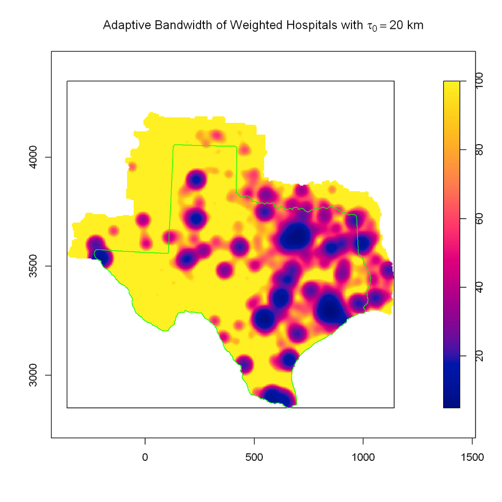

```r
hosTitle <- expression(paste("Adaptive Bandwidth of Weighted Hospitals with ", tau[0] ==
    20, " km"))
plot(hospitalKD$him, main = hosTitle)
plot(stateLineTess, border = "green", add = TRUE)
box()
axis(1)
axis(2)
```

The adaptive bandwidth clearly varies around the fixed global bandwidth of $\tau_0^{bed} = 20$ kilometers:

- In areas with a dense placement of hospitals the adaptive bandwidth drops to $\tau^{bed}(s_i)=10$ kilometers (~6 miles), which for urban areas is equivalent to approximately 20 minutes of travel time.
- In contrast, for sparsely populated rural areas the adaptive bandwidth increase to up to $\tau^{bed}(s_i)=100$ kilometers, which is equivalent to roughly 60 minutes of travel time.

## 4.2 Block Group Surface

```r
## bivariate density block group populations
bgKD <- bivariate.density(bgPts, h0 = 15, adapt = TRUE, weights = bgShp$POPCIVIL,
    edge = "diggle", xy = bivarDensXY(win))
```

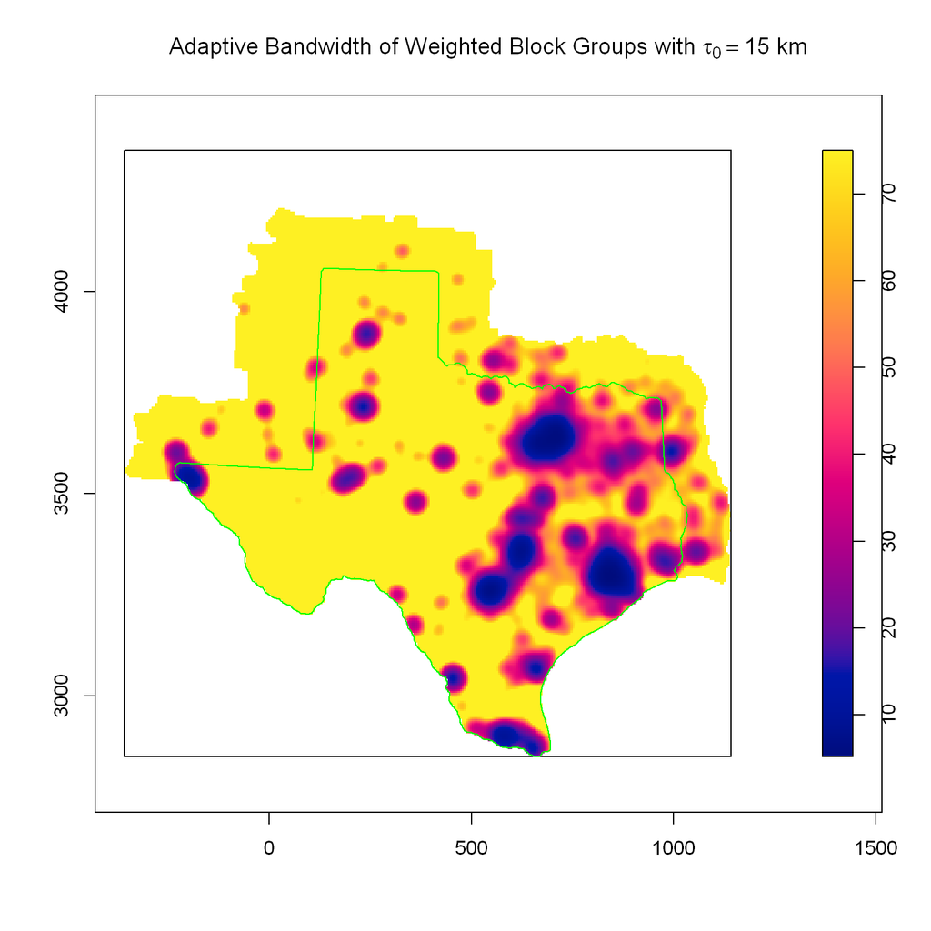

```r
bgTitle <- expression(paste("Adaptive Bandwidth of Weighted Block Groups with ",
    tau[0] == 15, " km"))
plot(bgKD$him, main = bgTitle)
plot(stateLineTess, border = "green", add = TRUE)
box()
axis(1)
axis(2)
```

The selected global bandwidth $\tau_0^{pop}=15$ kilometers was identified iteratively. It lead to a log-relative risk surface without major artifacts and a balanced distribution of the estimated log-relative risk values around the neutral value of zero.

It is reasonable to assume for the specialized services of hospitals to have larger *market areas* (i.e., $\tau_0^{bed} = 20$) than for the residents of areal units, whose daily activity field (i.e., $\tau_0^{pop}=15$) +usually is more constraint.

See the appendix for the *alternative specifications* of the population’s global bandwidths, that is, $\tau_0^{pop}=10$ and $\tau_0^{pop}=20$ kilometers.

# 5 Log-Relative Risk Surface with Significance Evaluation

The log-relative risk (LRR) compares the hospital bed supply density estimates $f_{bed}(s)$ against the population density demand estimates $f_{pop}(s)$ for each pixel location $s$ by

$$LLR(s) = \log \left(\frac{f_{bed}(s)}{f_{pop}(s)} \right)$$
We observe for
$$LLR(s) =\left\{
\begin{array}{ll}
< 0 & \mbox{under-supply} \\
\sim 0 & \mbox{balanced supply}\\
> 0 & \mbox{over-supply}
\end{array}
\right.$$
of the hospital capacities relative the population demand.

```r
## Risk surface
bivarateLRR <- risk(hospitalKD, bgKD, verbose = TRUE)

## Significance evaluation
tolLRR <- tolerance(bivarateLRR, method = "ASY", ITER = 100, verbose = TRUE, beta = 0.025)
```

```
## Initialising window...Done.
## Convolving bandwidth-categorised kernels with window:
##  --pass 1...Done.
##  --pass 2...Done.
##  --pass 3...Done.
##  --pass 4...Done.
```

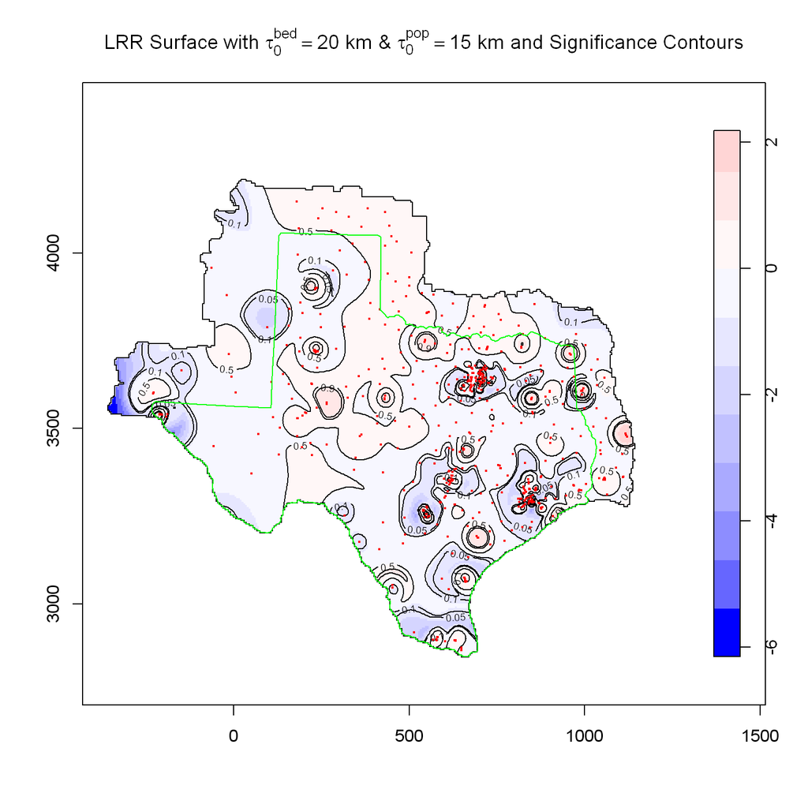

```r
## Plot logRR and significance
bound <- max(abs(range(bivarateLRR$rr$v, na.rm = TRUE)))

riskTitle <- expression(paste("LRR Surface with ", tau[0]^{
    bed
} == 20, " km & ", tau[0]^{
    pop
} == 15, " km and Significance Contours"))

plot(bivarateLRR, main = riskTitle, breaks = seq(-bound, bound, length.out = 16 +
    1), col = diverge_hsv(16))
tol.contour(tolLRR, test = "lower", levels = c(0.05, 0.1, 0.5, 0.9, 0.95), col = "black",
    add = TRUE)
plot(hospitalPts, col = "red", pch = 20, cex = 0.4, add = T)
plot(stateLineTess, border = "green", add = TRUE)
box()
axis(1)
axis(2)
```

This map displays two layers of information:

- The pixel layer is the log-relative risk, with **red** pixels indicating an over-supply of hospital beds relative to the population distributions and **blue** pixels *vice versa*.
- The isoline layer evaluates the significance, depicted here by the cumulative distribution function of the log-relative risk, of areas having excessive under-supply ($p < 0.05$) and over-supply ($p > 0.95$).

For Texas specific spatial pattern in the log-relative risk emerge:

- While immediate metropolitan cores - such as Dallas-Fort Worth, Houston, San Antonio and Austin - usually experience an over-supply their immediate periphery is under-supplied, because of a higher population numbers in the periphery relative to the cores and a concentration of major hospitals in the cores.

  Hospitals in smaller urban areas - such as Corpus Christi, Victoria, Galveston, Waco, Tyler, Texarkana, Paris, Gainswille, Wichia Falls and Amarillo - service their hinterlands better.
- Relative to the population density, the hospital supply for the mainly rural regions of the Edwards Plateau and the Low Rolling Plains in Central Texas and part of the Panhandle is higher than expected.

  Whereas, sparsely the populated Trans-Pecos in West Texas is under-supplied.
- The supply status along the Mexican border is mixed. The urban centers - such as Brownsville, McAllen, Laredo and to a minor degree El Paso - experience over-supply, most of the smaller communities along the border are under-supplied.

# 6 Hospital Accessibility by County

The individual log-relative risk pixel estimates are aggregated into the county level. For each county the following aggregated measures are used:

- The mean log-relative risk value `LRRDens` will become the target variable in a subsequent linear regression model.
- The variance `LRRVar` of the log-relative risk pixel values within each county allows capturing the degrees of uncertainty of the mean log-relative risk estimate `LRRDens` by implementing a heteroscedasticity adjustment to the regression model.

```r
## Aggregate kernel pixels into counties
riskStats <- densityKernelFct(bivarateLRR$rr, cntyTessIm)  #
summary(riskStats)
```

```
##      SeqId           nOfCells          Sum              Density
##  Min.   :  1.00   Min.   : 13.0   Min.   :-435.917   Min.   :-1.9532
##  1st Qu.: 64.25   1st Qu.: 87.0   1st Qu.: -56.859   1st Qu.:-0.5995
##  Median :127.50   Median : 99.0   Median : -21.510   Median :-0.2567
##  Mean   :127.50   Mean   :108.7   Mean   : -30.150   Mean   :-0.2767
##  3rd Qu.:190.75   3rd Qu.:110.0   3rd Qu.:   5.274   3rd Qu.: 0.0463
##  Max.   :254.00   Max.   :648.0   Max.   : 125.839   Max.   : 1.2584
##     varDens
##  Min.   :0.0003386
##  1st Qu.:0.0106493
##  Median :0.0348729
##  Mean   :0.0909359
##  3rd Qu.:0.1068605
##  Max.   :1.0422014
```

```r
countyShp$LRRDens <- riskStats$Density
countyShp$LRRVar <- riskStats$varDens
countyShp$LRRnOfCells <- riskStats$nOfCells

## Number of negative and possitive legend classes
sum(countyShp$LRRDens < 0)
```

```
## [1] 181
```

```r
sum(countyShp$LRRDens >= 0)
```

```
## [1] 73
```

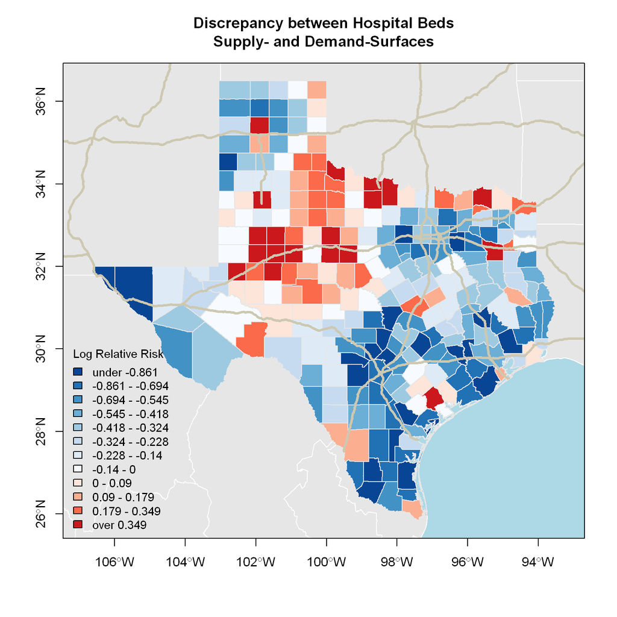

```r
## Plot county logRR
boundBox <- bbox(countyShp)
plot(neighShp, axes = TRUE, col = grey(0.9), border = "white", bg = "lightblue",
    xlim = boundBox[1, ], ylim = boundBox[2, ])

mapBiPolar(countyShp$LRRDens, countyShp, neg.breaks = 8, pos.breaks = 4, legend.cex = 0.9,
    map.title = "Discrepancy between Hospital Beds\nSupply- and Demand-Surfaces",
    legend.title = "Log Relative Risk", add.to.map = TRUE)

plot(hwyShp, col = "cornsilk3", lwd = 3, add = TRUE)
box()
```

# 7 Model Identification

## 7.1 Relevant Explanatory Variables

At the first step the influence of potential explanatory variables on the the spatial disparity of hospital accessibility is explored:

- The *political orientation* (`REPUBLIC`)of a county may indicate a potential leverage to obtain funding for local hospitals as well as a general mindset of the counties population towards health care.
- A high proportion of *uninsured population* (`UNINSURED`)stresses the health care supply.
- Counties with an *older population* (`MEDAGE`)will demand more health care.
- A high *birth rate* (`BIR15TO50`)in a county increases the demand for health care.
- Distance from the *Mexican border* (`DISTMEX`)reflects a cultural shift in attitudes in the county’s residents.
- The percentage of *black population* (`PARTBLACK`) may indicate disparities based on racial grounds.
- The percentage of *hispanic population* (`HISPORG`)may point towards disparities based on cultural grounds.
- The percentages of population with *college degrees* (`COLLEGEDEG`) or living in *poverty* (`POVERTY`) may hint at disparities based on socio-economic factors.

These proposed variables have the potential to explain any observed over- or under-supply for hospital beds in a county and enable political decision makers to take action.

## 7.2 Exploration

### 7.2.1 Scatterplot Matrix

```r
## Exploratory Regression Analysis
countyShp$DEMOCRAT <- countyShp$CLINTONVOT/countyShp$TOTALVOT16
countyShp$REPUBLIC <- countyShp$TRUMPVOT16/countyShp$TOTALVOT16

## Evaluate assymetry in the distributions of the independent variables
summary(powerTransform(cbind(REPUBLIC, UNINSURED, MEDAGE, BIR15TO50 = BIR15TO50 +
    10, DISTMEX, PARTBLACK = PARTBLACK + 0.01, HISPORG, COLLEGEDEG, POVERTY = POVERTY +
    0.05) ~ 1, family = "bcPower", data = countyShp))
```

```
## bcPower Transformations to Multinormality
##            Est Power Rounded Pwr Wald Lwr Bnd Wald Upr Bnd
## REPUBLIC      2.9939        2.99       2.5818       3.4061
## UNINSURED     0.5848        0.50       0.2345       0.9351
## MEDAGE        0.5488        1.00      -0.0846       1.1821
## BIR15TO50     0.8712        1.00       0.6918       1.0507
## DISTMEX       0.5713        0.50       0.4439       0.6988
## PARTBLACK     0.1960        0.20       0.0818       0.3101
## HISPORG       0.8641        0.86       0.7290       0.9992
## COLLEGEDEG    0.2788        0.33       0.0649       0.4928
## POVERTY       0.4397        0.50       0.1758       0.7037
##
## Likelihood ratio test that transformation parameters are equal to 0
##  (all log transformations)
##                                            LRT df       pval
## LR test, lambda = (0 0 0 0 0 0 0 0 0) 655.5316  9 < 2.22e-16
##
## Likelihood ratio test that no transformations are needed
##                                            LRT df       pval
## LR test, lambda = (1 1 1 1 1 1 1 1 1) 392.9501  9 < 2.22e-16
```

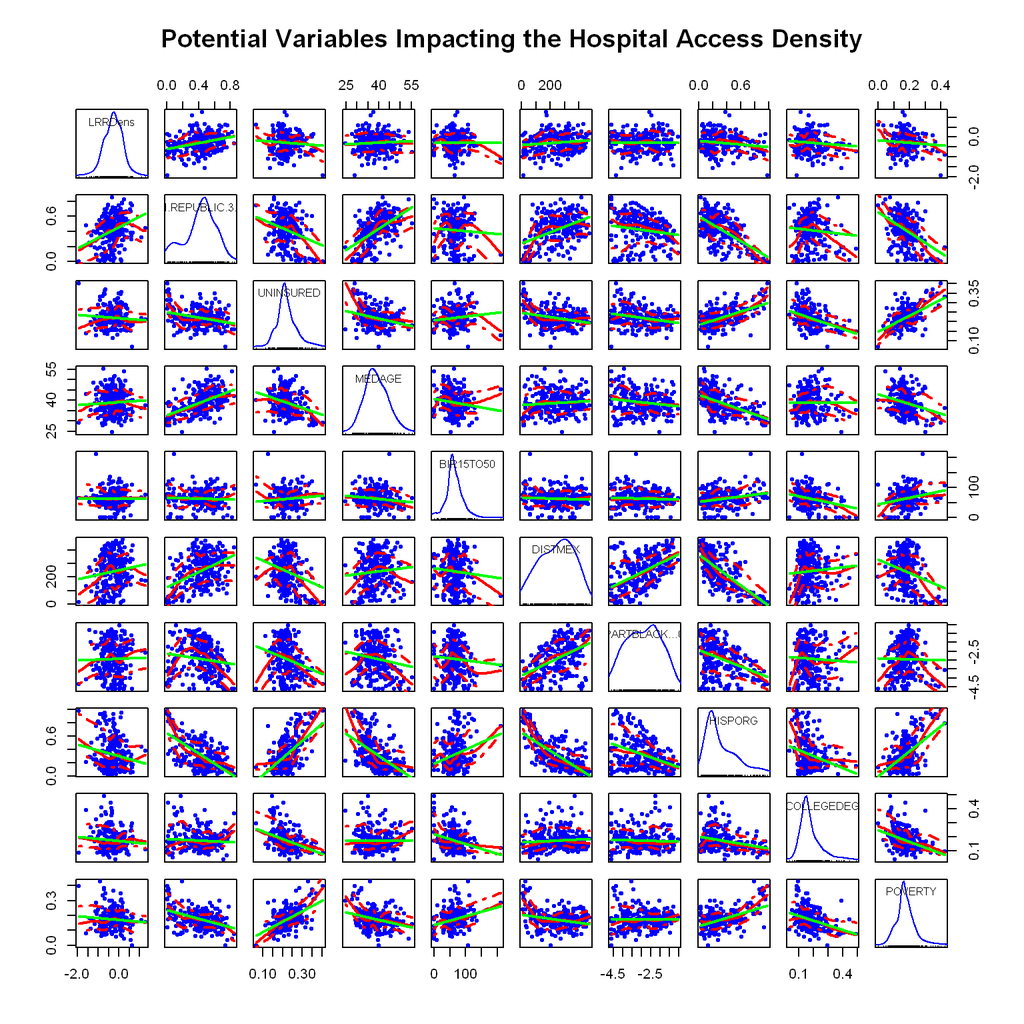

```r
## Pair-wise distribution of all variables
car::scatterplotMatrix(~LRRDens + I(REPUBLIC^3) + UNINSURED + MEDAGE + BIR15TO50 +
    DISTMEX + log(PARTBLACK + 0.01) + HISPORG + COLLEGEDEG + POVERTY, data = countyShp,
    main = "Potential Variables Impacting the Hospital Access Density", pch = 20,
    smooth = list(span = 0.35, lty.smooth = 1, col.smooth = "red", col.var = "red"),
    regLine = list(col = "green"))
```

The variables `BIR15TO50`, `PARTBLACK` and `POVERTY` have a few observations being equal to zero. These zeros prohibit determining their *Box-Cox* transformation parameters $\lambda$ in order to explore whether their distributions would benefit from the symmetry transformation $x^{[\lambda]}=\frac{(x^\lambda-1)}{\lambda}$. Thus, *offset* terms equal to their 5% quantile values were added these variable to achieve an all positive support.

### 7.2.2 Urban-rural Disparity

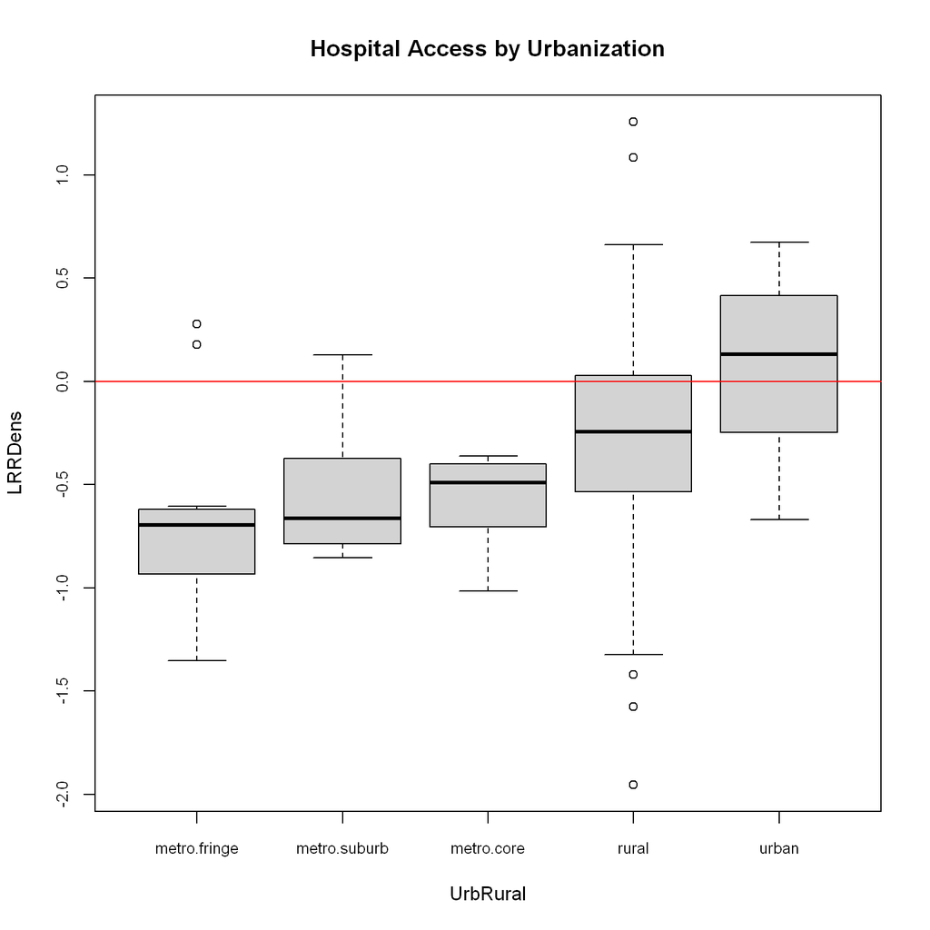

```r
UrbRural <- reorder(countyShp$URBRURAL, countyShp$LRRDens, median)
boxplot(LRRDens ~ UrbRural, cex.axis = 0.8, data = countyShp, main = "Hospital Access by Urbanization")
abline(h = 0, col = "red")
```

### 7.2.3 Dominant Regional Disparity

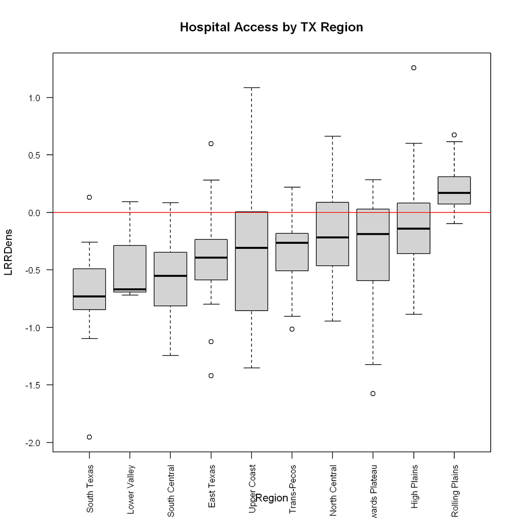

```r
Region <- reorder(countyShp$REGION, countyShp$LRRDens, median)
boxplot(LRRDens ~ Region, data = countyShp, cex.axis = 0.8, las = 2, main = "Hospital Access by TX Region")
abline(h = 0, col = "red")
```

### 7.2.4 Religious Adhesion

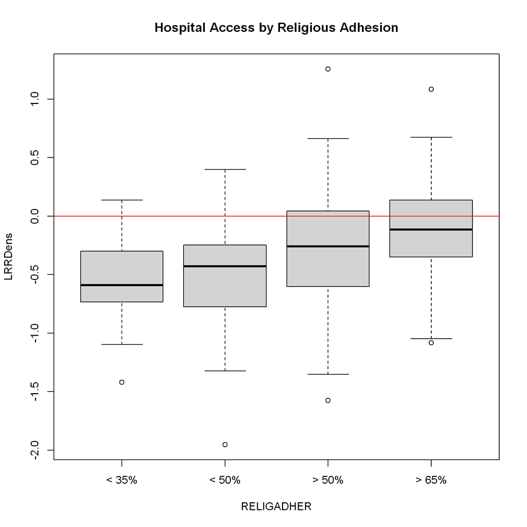

```r
boxplot(LRRDens ~ RELIGADHER, data = countyShp, main = "Hospital Access by Religious Adhesion")
abline(h = 0, col = "red")
```

## 7.3 Heteroscedasticity Regression Model

Due to the calculation of the dependent variable `LRRDENS` as average pixel value within the county boundaries, a variance is associated with `LRRDENS`. This causes *heteroscedasticity* in the regression model.

The weighted regression model `lm.03` accounts for this heteroscedasticity through an estimated weights variable `weights=lm.02$weights`, which was determined in the `lmHetero` function of the model `lm.02`.

```r
## heteroscedasticity investigation
lm.02 <- lmHetero(LRRDens ~ I(REPUBLIC^3) + DISTMEX + log(PARTBLACK + 0.01) + RELIGADHER |
    log(LRRVar), data = countyShp)
summary(lm.02)
```

```
##
## ================================================================
## Multiplicatively Weighted Heteroscedasticity ML-Regression Model
## ================================================================
##
## Call:
## lmHetero(formula = LRRDens ~ I(REPUBLIC^3) + DISTMEX + log(PARTBLACK +
##     0.01) + RELIGADHER | log(LRRVar), data = countyShp)
##
## Regression Coefficients:
##                          Estimate     Std.Err z-value  Pr(>|z|)
## (Intercept)           -0.40910018  0.16193651 -2.5263 0.0115271 *
## I(REPUBLIC^3)          0.81183145  0.15811847  5.1343 2.832e-07 ***
## DISTMEX               -0.00068814  0.00027652 -2.4885 0.0128270 *
## log(PARTBLACK + 0.01)  0.08478843  0.03205488  2.6451 0.0081666 **
## RELIGADHER< 50%        0.07591574  0.11946415  0.6355 0.5251227
## RELIGADHER> 50%        0.26279278  0.11761698  2.2343 0.0254627 *
## RELIGADHER> 65%        0.38299564  0.11421794  3.3532 0.0007988 ***
## ---
## Signif. codes:  0 '***' 0.001 '**' 0.01 '*' 0.05 '.' 0.1 ' ' 1
##
## Gamma Coefficients:
##                 Gamma   Std.Err z-value  Pr(>|z|)
## (Intercept) -0.811232  0.214136 -3.7884 0.0001516 ***
## log(LRRVar)  0.311851  0.056481  5.5214 3.364e-08 ***
## ---
## Signif. codes:  0 '***' 0.001 '**' 0.01 '*' 0.05 '.' 0.1 ' ' 1
##
## log-likelihood = -120.7276
##
## Heteroscedasticity likelihood ratio test:
##        LR   df  Pr(Chi > LR)
##  24.84902    1  6.200046e-07
```

```r
## build weighted OLS model
lm.03 <- lm(LRRDens ~ I(REPUBLIC^3) + DISTMEX + log(PARTBLACK + 0.01) + RELIGADHER,
    weights = lm.02$weights, data = countyShp)
car::vif(lm.03)
```

```
##                           GVIF Df GVIF^(1/(2*Df))
## I(REPUBLIC^3)         1.705400  1        1.305910
## DISTMEX               2.020058  1        1.421287
## log(PARTBLACK + 0.01) 1.696286  1        1.302415
## RELIGADHER            1.111550  3        1.017782
```

From the proposed set of initial variables a group of relevant explanatory variables were identified in several rounds of *exploring different model specifications*.

Interpretation of the heteroscedastic model:

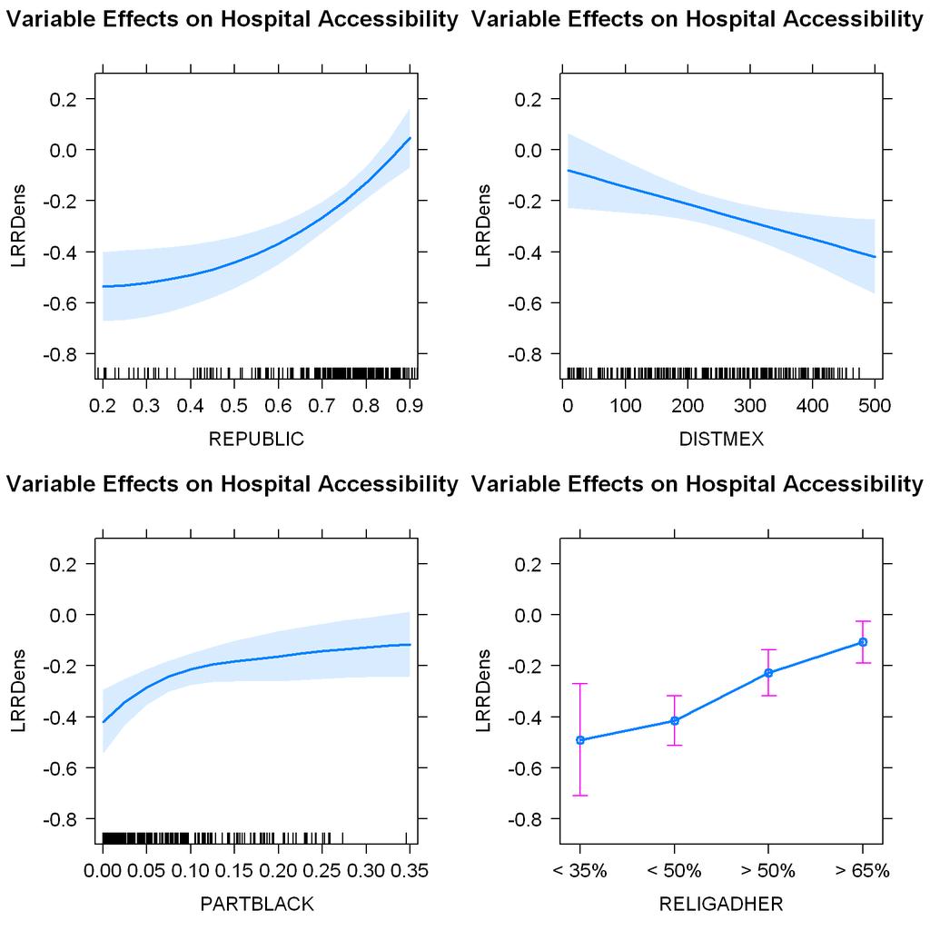

```r
## Effects plots
plot(allEffects(lm.03), ylim = c(-0.9, 0.3), main = "Variable Effects on Hospital Accessibility")
```

## 7.4 Model Diagnostics

The model diagnostics for the weighted regression model show a *lack of major violations* of the model’s assumptions.

### 7.4.1 Non linearity

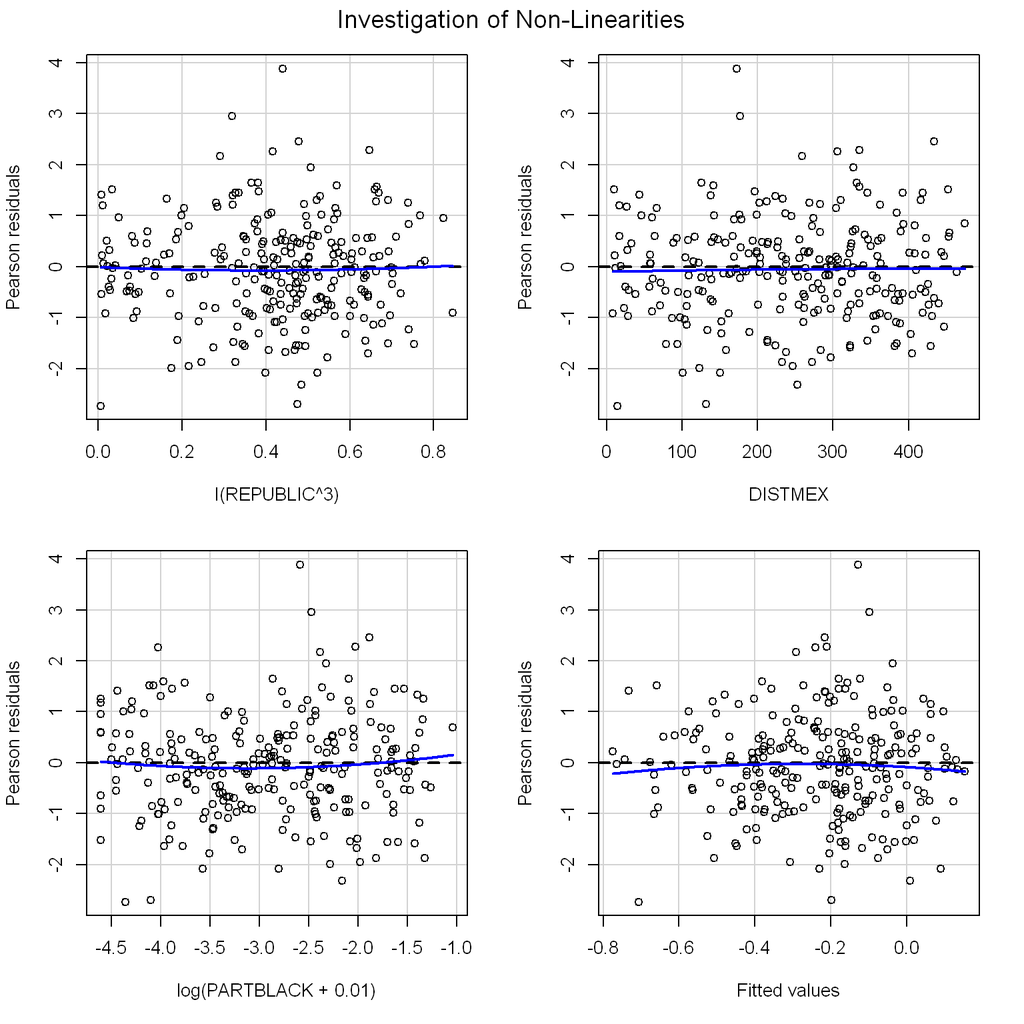

```
##                       Test stat Pr(>|Test stat|)
## I(REPUBLIC^3)           -5.6323        4.845e-08 ***
## DISTMEX                 -5.3209        2.323e-07 ***
## log(PARTBLACK + 0.01)   -6.1603        2.942e-09 ***
## Tukey test              -2.5686          0.01021 *
## ---
## Signif. codes:  0 '***' 0.001 '**' 0.01 '*' 0.05 '.' 0.1 ' ' 1
```

```r
## explore non-linearity check
car::residualPlots(lm.03, main = "Investigation of Non-Linearities")
```

The exogenous variables are *properly specified*. Despite showing some significance, visual inspection indicates that adding quadratic terms to some of the variables or additional log-transformations can be by-passed.

### 7.4.2 Outliers

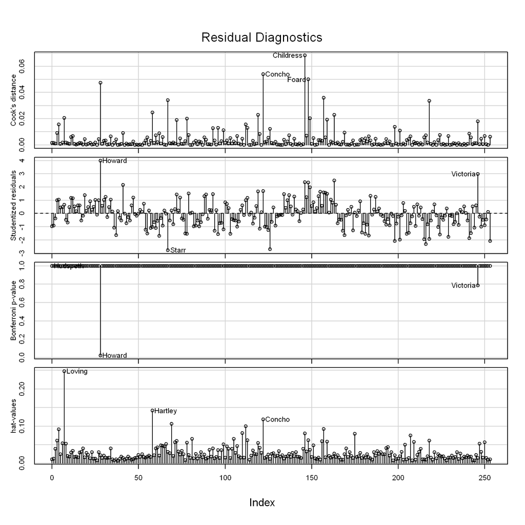

```r
## residual scan
car::influenceIndexPlot(lm.03, id = list(n = 3, labels = countyShp$NAME), main = "Residual Diagnostics")
```

The only outlier according to Bonferroni $p$-values of the studentized residuals is *Howard* County along interstate 20 in the southern part of the High Plains. Its over-supply is substantially higher than expected based on the explanatory variables.

### 7.4.3 Residual Normality

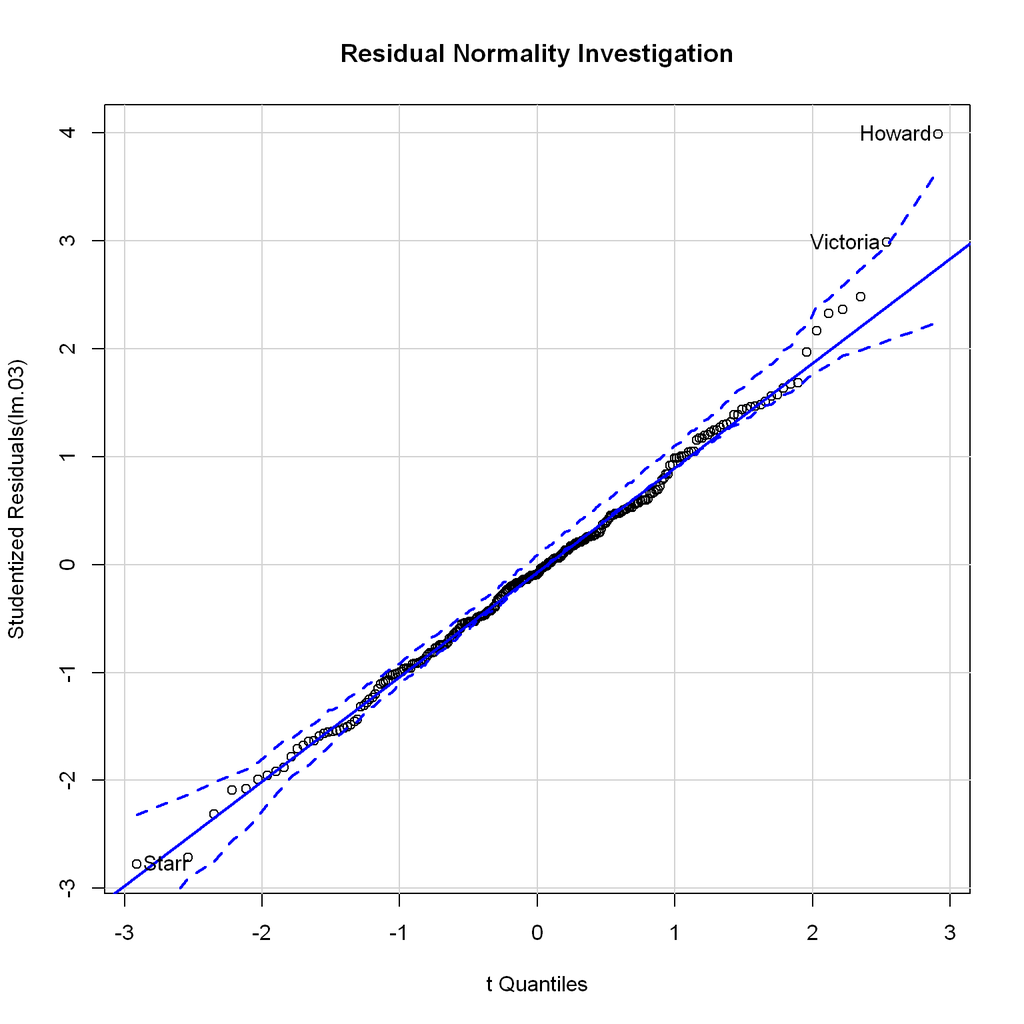

```
##   Howard    Starr Victoria
##       29       68      247
```

```r
## Normality test
qqPlot(lm.03, id = list(n = 3, labels = countyShp$NAME), main = "Residual Normality Investigation")
```

# 8 Spatial Residual Diagnostics

## 8.1 Spatial Pattern

```r
## spatial residual diagonstics
proj4string(countyShp)  # map projection
```

```
## [1] "+proj=longlat +ellps=GRS80 +no_defs"
```

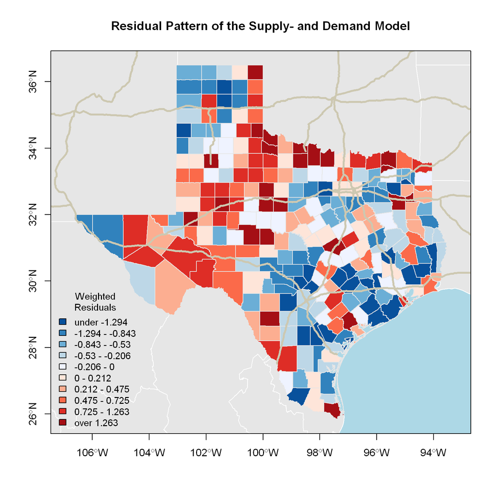

```r
centroid <- coordinates(countyShp)  # get province centroids
boundBox <- bbox(countyShp)  # province bounding box for map region
link <- poly2nb(countyShp, queen = F)  # generate neighbors links
linkW <- nb2listw(link, style = "W")  # generated row-sum standardized neighbors list
wResid <- weighted.residuals(lm.03)

## Residual map pattern
plot(neighShp, axes = T, col = grey(0.9), border = "white", bg = "lightblue", xlim = boundBox[1,
    ], ylim = boundBox[2, ])
mapBiPolar(wResid, countyShp, neg.breaks = 5, pos.breaks = 5, legend.cex = 0.9, map.title = "Residual Pattern of the Supply- and Demand Model",
    legend.title = "Weighted\nResiduals", add.to.map = TRUE)
plot(hwyShp, col = "cornsilk3", lwd = 3, add = TRUE)
box()
```

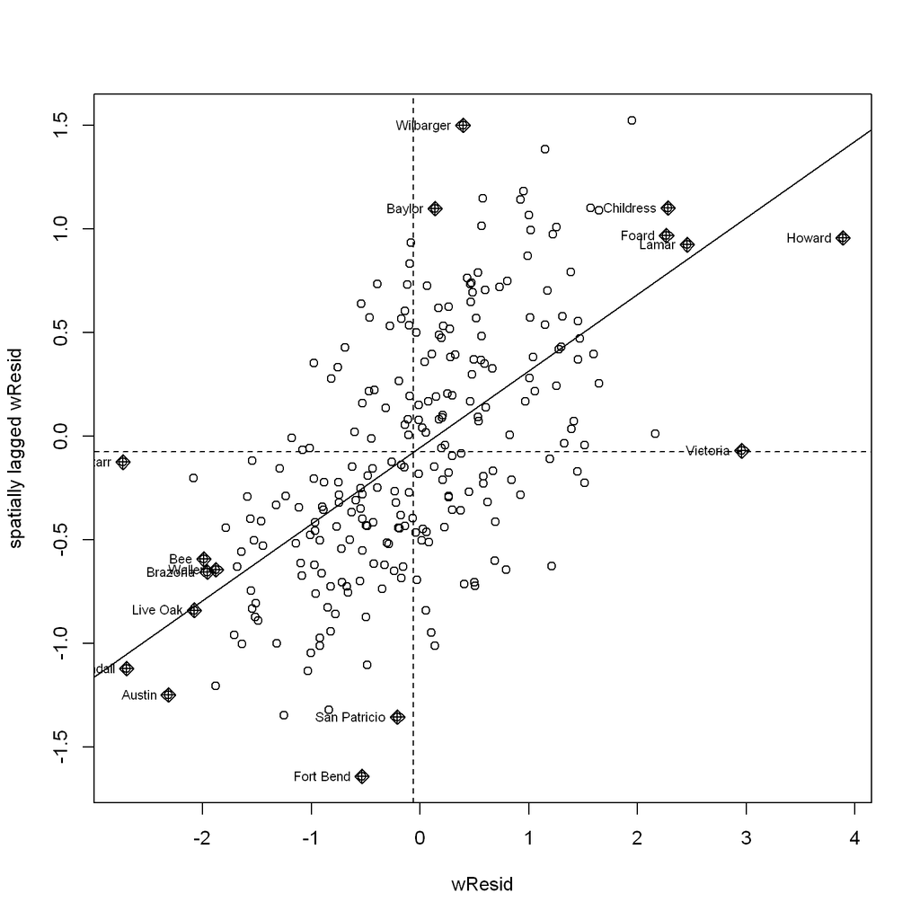

```r
## Descriptive diagnostics
moran.plot(wResid, linkW, labels = countyShp$NAME)  # Moran plot with outlier diagnositics
```

```r
lm.morantest(lm.03, linkW)  # test with W-coding scheme
```

```
##
##  Global Moran I for regression residuals
##
## data:
## model: lm(formula = LRRDens ~ I(REPUBLIC^3) + DISTMEX + log(PARTBLACK +
## 0.01) + RELIGADHER, data = countyShp, weights = lm.02$weights)
## weights: linkW
##
## Moran I statistic standard deviate = 9.9395, p-value < 2.2e-16
## alternative hypothesis: greater
## sample estimates:
## Observed Moran I      Expectation         Variance
##      0.372477622     -0.012848592      0.001502901
```

The *weighted residual pattern* exhibits substantial spatial clustering in the regression residuals and strong positive spatial autocorrelation.

## 8.2 Correlogram

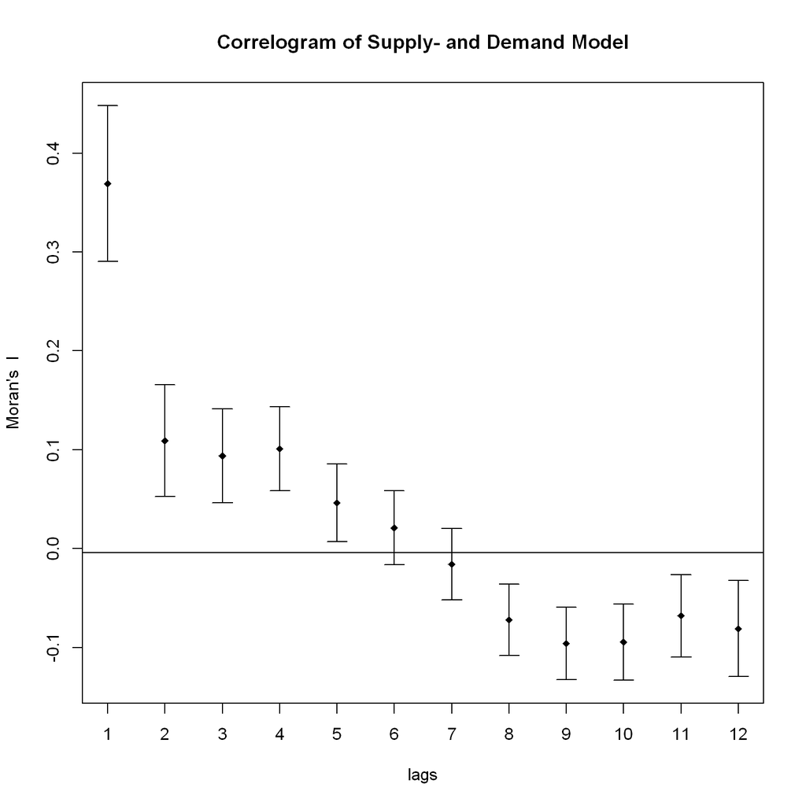

```r
## Correlogram
plot(sp.correlogram(link, wResid, order=12,          # correlogram
                    method="I", style = "W"),
     main="Correlogram of Supply- and Demand Model")
```

The slowly vanishing and, perhaps, oscillating autocorrelation level for increasing spatial lags in **correlogram** indicates that the underlying *data generating mechanism* is more complex than what would be expected either for

- a *simultaneous autoregressive (SAR)* process or
- a *spatial lag (LAG)* process.

Consequently, neither the SAR nor the LAG models will provide meaningful estimates for this potentially non-stationary data generating process.

# 9 Conclusions

This study as shown, while the travel distances in rural Texas are substantially longer to obtain access to health care, that the provision of health care relative to the population density is adequate for most areas.

## 9.1 Key Findings

- Adaptive bandwidth kernel estimation is preferred over fixed bandwidth for regions that are as heterogeneous as Texas:
  - for urbanized areas the average travel distance was around 10 km (~20 minutes travel time), whereas
  - for remote rural areas the distance increased to 100 km (~60 minutes travel time).
- Counties, which surround metropolitan cores, are generally under-served.
- Interestingly, sparsely populated rural counties in central Texas and the Panhandle as well as some counties along the Mexican border experienced an over-supply relative to their population demanding health care.
- The Republican political affiliation of a county’s population as well as religious adhesion favorably led to an over-supply of hospital capacities. So did a strong Afro-american population segment, which mainly is concentrated in metropolitan cores.

## 9.2 Model Refinements

- Rather than using adaptive weighted kernel densities based on euclidean distances, densities based on *travel times along the state’s street network* can be evaluated.
- Rather than aggregating the log-relative risk kernel pixels into counties, the analysis could be repeated on the census tract level. This *finer spatial resolution* may reveal, subject to available data, further relevant factors capturing any over- or under-supply patterns.

  Having this analysis encoded as a `R Markdown` document easily enables *reproduction* of this study with an augmented dataset.

  However, one needs to bear in mind that decisions such as opening or closing a hospital, its location and capacity regularly require the involvement of *broader jurisdictions* on the county level.

## 9.3 Possible Generalizations

- Log-relative risk ratios are frequently used in **epidemiological** studies to compare the density of *cases* with a particular diseases and ailments against the density of *controls* comprising of the underlying population at risk.
- Log-relative risk ratios are less frequently used in **economic** settings to evaluate imbalances between the local *demand* and *supply* for goods and services as well as the identification of of the range of *market areas*. Log-relative risk ratios clearly provide a methodology for further economic studies.
- By **integrating** log-relative risk ratio pixels into larger statistical units, aggregated discrepancies can be linked to external areal characteristics. This additional information allows *explaining* observed discrepancies in a regression setting.

# 10 References

# 11 Appendices

## 11.1 Bandwidth Experimentations

### 11.1.1 Population Density with $\tau_0 = 10$ km

```r
bgKD10 <- bivariate.density(bgPts, h0 = 10, adapt = TRUE, weights = bgShp$POPCIVIL,
    edge = "diggle", xy = bivarDensXY(win))
bivarateLRR10 <- risk(hospitalKD, bgKD10, verbose = TRUE)
tolLRR10 <- tolerance(bivarateLRR10, method = "ASY", ITER = 100, verbose = TRUE,
    beta = 0.025)
```

```
## Initialising window...Done.
## Convolving bandwidth-categorised kernels with window:
##  --pass 1...Done.
##  --pass 2...Done.
##  --pass 3...Done.
##  --pass 4...Done.
```

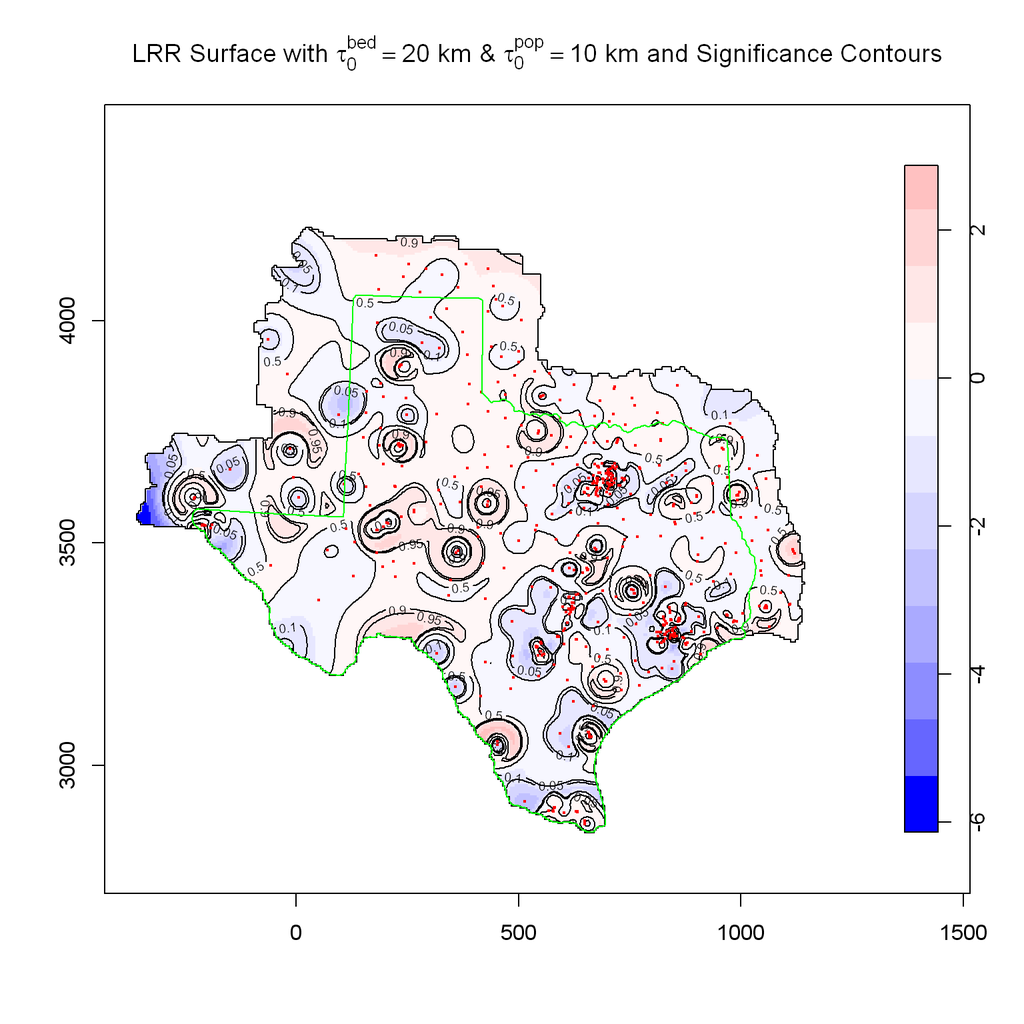

```r
## Plot logRR and significance
bound <- max(abs(range(bivarateLRR10$rr$v, na.rm = TRUE)))

riskTitle <- expression(paste("LRR Surface with ", tau[0]^{
    bed
} == 20, " km & ", tau[0]^{
    pop
} == 10, " km and Significance Contours"))

plot(bivarateLRR10, main = riskTitle, breaks = seq(-bound, bound, length.out = 16 +
    1), col = diverge_hsv(16))
tol.contour(tolLRR10, test = "lower", levels = c(0.05, 0.1, 0.5, 0.9, 0.95), col = "black",
    add = TRUE)
plot(hospitalPts, col = "red", pch = 20, cex = 0.4, add = T)
plot(stateLineTess, border = "green", add = TRUE)
box()
axis(1)
axis(2)
```

### 11.1.2 Population Density with $\tau_0 = 20$ km

```r
bgKD20 <- bivariate.density(bgPts, h0 = 20, adapt = TRUE, weights = bgShp$POPCIVIL,
    edge = "diggle", xy = bivarDensXY(win))
bivarateLRR20 <- risk(hospitalKD, bgKD20, verbose = TRUE)
tolLRR20 <- tolerance(bivarateLRR20, method = "ASY", ITER = 100, verbose = TRUE,
    beta = 0.025)
```

```
## Initialising window...Done.
## Convolving bandwidth-categorised kernels with window:
##  --pass 1...Done.
##  --pass 2...Done.
##  --pass 3...Done.
##  --pass 4...Done.
```

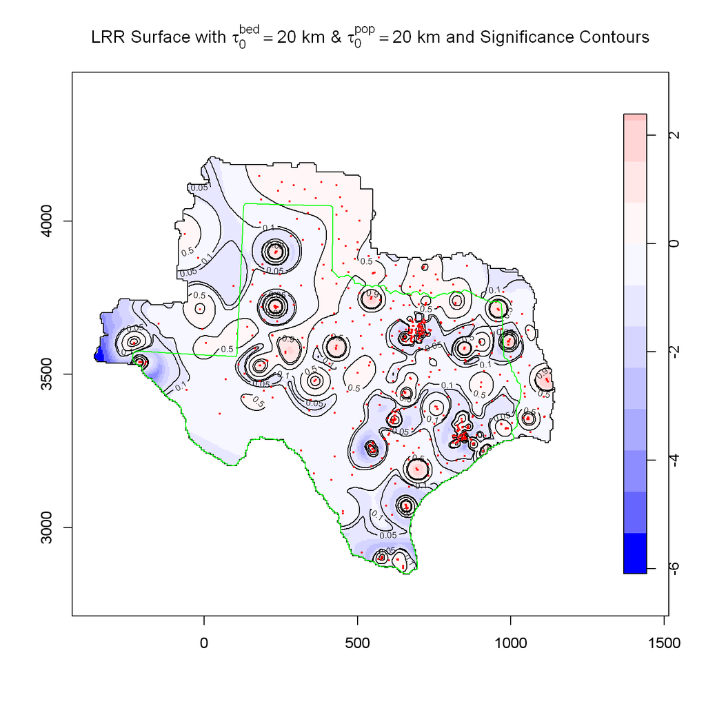

```r
## Plot logRR and significance
bound <- max(abs(range(bivarateLRR20$rr$v, na.rm = TRUE)))

riskTitle <- expression(paste("LRR Surface with ", tau[0]^{
    bed
} == 20, " km & ", tau[0]^{
    pop
} == 20, " km and Significance Contours"))

plot(bivarateLRR20, main = riskTitle, breaks = seq(-bound, bound, length.out = 16 +
    1), col = diverge_hsv(16))
tol.contour(tolLRR20, test = "lower", levels = c(0.05, 0.1, 0.5, 0.9, 0.95), col = "black",
    add = TRUE)
plot(hospitalPts, col = "red", pch = 20, cex = 0.4, add = T)
plot(stateLineTess, border = "green", add = TRUE)
box()
axis(1)
axis(2)
```

## 11.2 Adaptive Kernel Densities

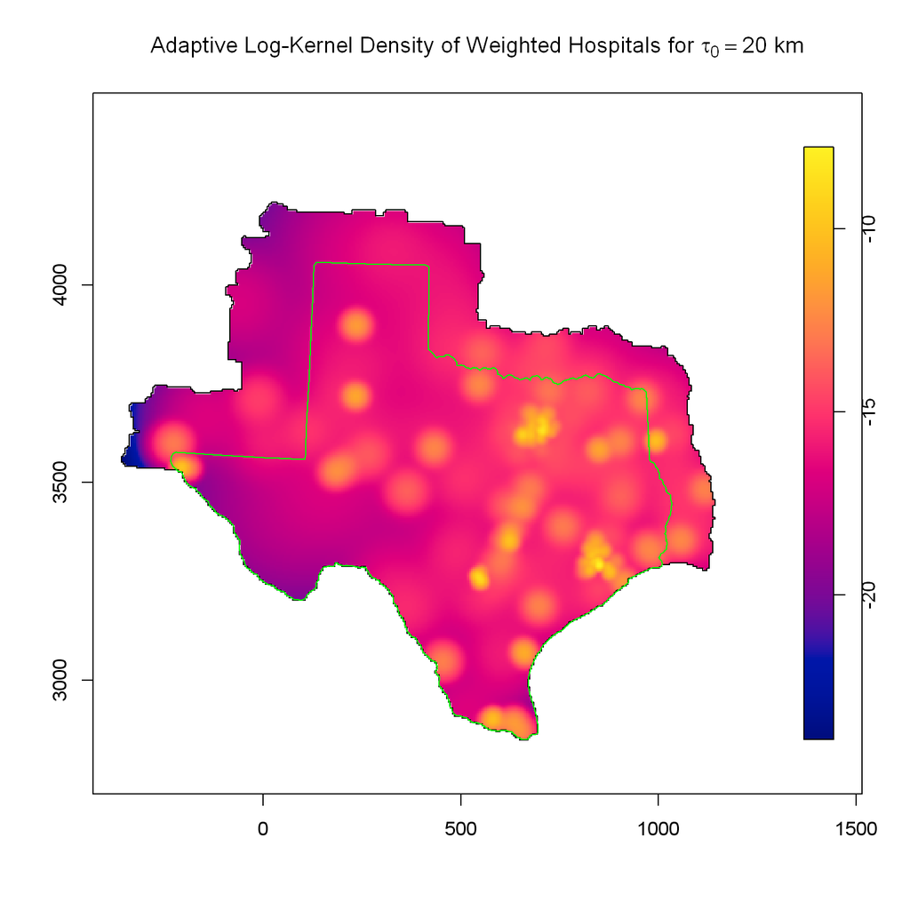

```r
adaptTitle <- expression(paste("Adaptive Log-Kernel Density of Weighted Hospitals for ",
    tau[0] == 20, " km"))
tempKD <- hospitalKD
tempKD$z$v <- log(hospitalKD$z$v)
plot(tempKD, main = adaptTitle)
plot(stateLineTess, border = "green", add = TRUE)
box()
axis(1)
axis(2)
```

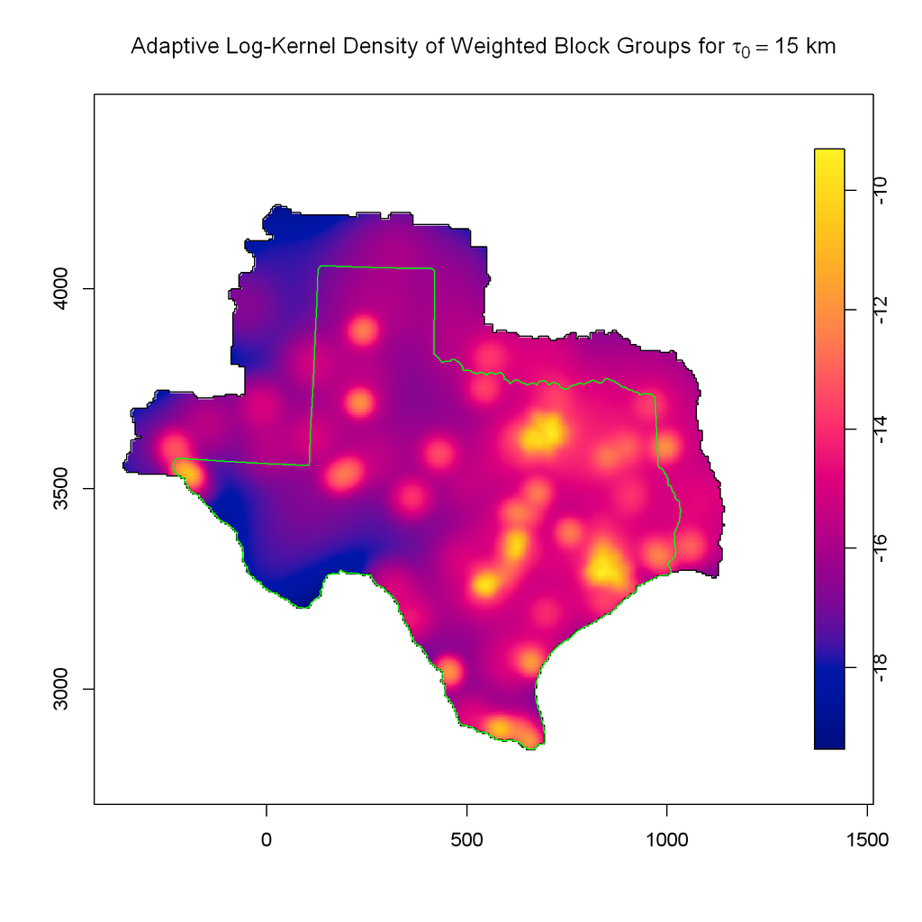

```r
adaptTitle <- expression(paste("Adaptive Log-Kernel Density of Weighted Block Groups for ",
    tau[0] == 15, " km"))
tempKD <- bgKD
tempKD$z$v <- log(bgKD$z$v)
plot(tempKD, main = adaptTitle)
plot(stateLineTess, border = "green", add = TRUE)
box()
axis(1)
axis(2)
```

```r
rm(tempKD)
```

## 11.3 Initial Regression Model

```r
lm.01 <- lm(LRRDens ~ I(REPUBLIC^3) + UNINSURED + MEDAGE + BIR15TO50 + DISTMEX +
    log(PARTBLACK + 0.01) + HISPORG + COLLEGEDEG + POVERTY + URBRURAL + RELIGADHER,
    data = countyShp)
summary(lm.01)
```

```
##
## Call:
## lm(formula = LRRDens ~ I(REPUBLIC^3) + UNINSURED + MEDAGE + BIR15TO50 +
##     DISTMEX + log(PARTBLACK + 0.01) + HISPORG + COLLEGEDEG +
##     POVERTY + URBRURAL + RELIGADHER, data = countyShp)
##
## Residuals:
##     Min      1Q  Median      3Q     Max
## -1.2040 -0.2165  0.0203  0.2447  1.4096
##
## Coefficients:
##                         Estimate Std. Error t value Pr(>|t|)
## (Intercept)            0.1195532  0.5331298   0.224 0.822758
## I(REPUBLIC^3)          1.0044868  0.2876341   3.492 0.000571 ***
## UNINSURED             -0.6919963  0.7182931  -0.963 0.336334
## MEDAGE                -0.0090889  0.0076849  -1.183 0.238113
## BIR15TO50             -0.0006438  0.0010233  -0.629 0.529831
## DISTMEX               -0.0006368  0.0003752  -1.697 0.090945 .
## log(PARTBLACK + 0.01)  0.0496237  0.0511932   0.969 0.333364
## HISPORG               -0.0887719  0.3562364  -0.249 0.803427
## COLLEGEDEG            -0.7646476  0.5971052  -1.281 0.201589
## POVERTY                0.1835824  0.5509667   0.333 0.739277
## URBRURALmetro.fringe  -0.2636569  0.2186355  -1.206 0.229051
## URBRURALmetro.suburb   0.0660101  0.2299029   0.287 0.774270
## URBRURALrural         -0.0832439  0.1995284  -0.417 0.676907
## URBRURALurban          0.4417858  0.2044352   2.161 0.031697 *
## RELIGADHER< 50%        0.0532633  0.1227597   0.434 0.664768
## RELIGADHER> 50%        0.2344096  0.1202345   1.950 0.052403 .
## RELIGADHER> 65%        0.3193255  0.1202647   2.655 0.008464 **
## ---
## Signif. codes:  0 '***' 0.001 '**' 0.01 '*' 0.05 '.' 0.1 ' ' 1
##
## Residual standard error: 0.3959 on 237 degrees of freedom
## Multiple R-squared:  0.3011, Adjusted R-squared:  0.2539
## F-statistic: 6.381 on 16 and 237 DF,  p-value: 7.773e-12
```

```r
car::vif(lm.01)
```

```
##                            GVIF Df GVIF^(1/(2*Df))
## I(REPUBLIC^3)          5.155976  1        2.270677
## UNINSURED              1.999126  1        1.413905
## MEDAGE                 2.841801  1        1.685764
## BIR15TO50              1.253636  1        1.119659
## DISTMEX                3.370542  1        1.835903
## log(PARTBLACK + 0.01)  3.582665  1        1.892793
## HISPORG               10.962336  1        3.310942
## COLLEGEDEG             2.933110  1        1.712632
## POVERTY                2.000561  1        1.414412
## URBRURAL               3.258192  4        1.159103
## RELIGADHER             1.412227  3        1.059215
```

## 11.4 Spatial Regression Models

### 11.4.1 Heteroscedastic Spatial Autoregressive Model

```r
## SAR model accounting for heteroscedasticity
LRR.SAR <- spatialreg::spautolm(LRRDens ~ I(REPUBLIC^3) + DISTMEX + log(PARTBLACK +
    0.01) + RELIGADHER, weights = lm.02$weights, data = countyShp, na.action = "na.omit",
    listw = linkW, family = "SAR")
summary(LRR.SAR)
```

```
##
## Call: spatialreg::spautolm(formula = LRRDens ~ I(REPUBLIC^3) + DISTMEX +
##     log(PARTBLACK + 0.01) + RELIGADHER, data = countyShp, listw = linkW,
##     weights = lm.02$weights, na.action = "na.omit", family = "SAR")
##
## Residuals:
##       Min        1Q    Median        3Q       Max
## -1.273885 -0.164697 -0.012929  0.139892  1.240585
##
## Coefficients:
##                          Estimate  Std. Error z value Pr(>|z|)
## (Intercept)           -0.36351629  0.22537088 -1.6130   0.1068
## I(REPUBLIC^3)         -0.07213248  0.15456710 -0.4667   0.6407
## DISTMEX                0.00068757  0.00067642  1.0165   0.3094
## log(PARTBLACK + 0.01)  0.00534130  0.03024580  0.1766   0.8598
## RELIGADHER< 50%        0.06029701  0.08277860  0.7284   0.4664
## RELIGADHER> 50%        0.09788444  0.07956988  1.2302   0.2186
## RELIGADHER> 65%        0.10109656  0.08067260  1.2532   0.2101
##
## Lambda: 0.80722 LR test value: 120.52 p-value: < 2.22e-16
## Numerical Hessian standard error of lambda: 0.042966
##
## Log likelihood: -60.46891
## ML residual variance (sigma squared): 0.51569, (sigma: 0.71811)
## Number of observations: 254
## Number of parameters estimated: 9
## AIC: 138.94
```

```r
## Evaluate ML residuals for spatial autocorrelation
moran.mc(residuals(LRR.SAR), linkW, nsim = 9999)
```

```
##
##  Monte-Carlo simulation of Moran I
##
## data:  residuals(LRR.SAR)
## weights: linkW
## number of simulations + 1: 10000
##
## statistic = -0.0088626, observed rank = 4633, p-value = 0.5367
## alternative hypothesis: greater
```

### 11.4.2 Heterocedastic Spatial Lag Model

```r
## LAG model
LRR.lag <- spatialreg::lagsarlm(lm.03, data = countyShp, linkW, type = "lag")
summary(LRR.lag)
```

```
##
## Call:spatialreg::lagsarlm(formula = lm.03, data = countyShp, listw = linkW,
##     type = "lag")
##
## Residuals:
##         Min          1Q      Median          3Q         Max
## -1.15291831 -0.15735284 -0.00066952  0.15340879  1.22137053
##
## Type: lag
## Coefficients: (asymptotic standard errors)
##                          Estimate  Std. Error z value Pr(>|z|)
## (Intercept)           -0.16064695  0.13486909 -1.1911  0.23360
## I(REPUBLIC^3)          0.14467633  0.13300083  1.0878  0.27669
## DISTMEX               -0.00010292  0.00023725 -0.4338  0.66444
## log(PARTBLACK + 0.01)  0.03962360  0.02851015  1.3898  0.16459
## RELIGADHER< 50%        0.08824365  0.09488899  0.9300  0.35239
## RELIGADHER> 50%        0.19124764  0.09335836  2.0485  0.04051
## RELIGADHER> 65%        0.21935776  0.09322552  2.3530  0.01862
##
## Rho: 0.72145, LR test value: 102.7, p-value: < 2.22e-16
## Asymptotic standard error: 0.050004
##     z-value: 14.428, p-value: < 2.22e-16
## Wald statistic: 208.16, p-value: < 2.22e-16
##
## Log likelihood: -81.80208 for lag model
## ML residual variance (sigma squared): 0.097094, (sigma: 0.3116)
## Number of observations: 254
## Number of parameters estimated: 9
## AIC: 181.6, (AIC for lm: 282.3)
## LM test for residual autocorrelation
## test value: 0.079025, p-value: 0.77862
```

```r
## Evaluate ML residuals for spatial autocorrelation
moran.mc(residuals(LRR.lag), linkW, nsim = 9999)
```

```
##
##  Monte-Carlo simulation of Moran I
##
## data:  residuals(LRR.lag)
## weights: linkW
## number of simulations + 1: 10000
##
## statistic = 0.0050939, observed rank = 6032, p-value = 0.3968
## alternative hypothesis: greater
```